# Module_2_3

## Using simulations

Today, we’re going to be talking about simulating data. Not in a ‘making up data’ unethical framework, but using our assumptions and knowledge about to build simulated data, and then comparing that to data we’ve collected. This has a number of benefits over just comparing to summary statistics of data…

We’ll talk about all of this in a second.

## Scenario - Research is costly

So here is the basic scenario. We found a correlation between eating fish and people getting sick, but that isn’t really the root of the problem. We don’t actually know if rates of disease are present above average levels in the tanks, and we definitely don’t know what kinds of factors are contributing to this problem (if there is one!).

Let’s scope it out:

```r
library(tidyverse)
sick_fish = read_csv("https://tinyurl.com/yf3pv3am")
glimpse(sick_fish)
```

```
## Observations: 50
## Variables: 8
## $ tank_id        <dbl> 331, 580, 925, 996, 472, 171, 903, 777, 279, 734, 912,…
## $ species        <chr> "tilapia", "tilapia", "trout", "trout", "tilapia", "ti…
## $ avg_daily_temp <dbl> 24.82100, 23.62557, 14.01980, 14.69082, 23.82299, 23.7…
## $ num_fish       <dbl> 99, 98, 73, 78, 104, 97, 75, 62, 94, 99, 60, 100, 101,…
## $ day_length     <dbl> 9, 10, 12, 11, 10, 10, 14, 12, 8, 10, 12, 11, 11, 10, …
## $ tank_volume    <dbl> 399.7492, 399.4314, 400.6617, 399.9064, 400.3092, 399.…
## $ num_sick       <dbl> 0, 7, 14, 19, 1, 2, 18, 12, 8, 13, 19, 18, 3, 16, 4, 1…
## $ size_day_30    <dbl> 2779.6720, 2780.1393, 147.5595, 149.5450, 2789.2763, 2…
```

## Group challenge

What is the mean number of sick fish for each species (both in terms of numbers and percentage of the entire tank?

```r
sick_fish %>%
  group_by(species) %>%
  summarize(mean_sick = mean(num_sick),
            mean_perc = mean(num_sick/num_fish),
            n = n())
```

```
## # A tibble: 2 x 4
##   species mean_sick mean_perc     n
##   <chr>       <dbl>     <dbl> <int>
## 1 tilapia       6      0.0597    33
## 2 trout        12.8    0.177     17
```

## Justifying a simulation

This seems high, at least for trout, but it could be that it’s high because of a biased sample, right? Maybe we just happened to pick tanks (17 out of 250), with higher numbers. Can we simulate some draws based on an acceptable disease percentage and see what we end up getting and then compare this to what our aquaculture scientists provided us?

```r
# We know our expected outcomes for disease rates in tanks:
# Tilapia = 4%
# Trout = 9%

# Let's generate some data for tilapia to start
# How many fish do we have in each tank? Well, it varies, but on average, it's...
fish_tank_data = read_csv("https://tinyurl.com/tbyskxl")
fish_tank_data %>%
  group_by(species) %>%
  summarize(mean_num_fish = mean(num_fish))
```

```
## # A tibble: 2 x 2
##   species mean_num_fish
##   <chr>           <dbl>
## 1 tilapia          99.8
## 2 trout            74.2
```

```r
# About 100 for tilapia and 74 for trout.
# So 4% of 100 is 4, we expect about 4 sick for each tank, but this is on
# average...
```

## The normal distribution

So, we want to build a simulation that is 4 fish sick on average from a tank, but we want to realistically simulate natural variation across fish tanks. There aren’t going to be exactly 4 fish sick in every tank if we have our expectations. We can simulate this using something called the normal distribution, which is just a bell curve.

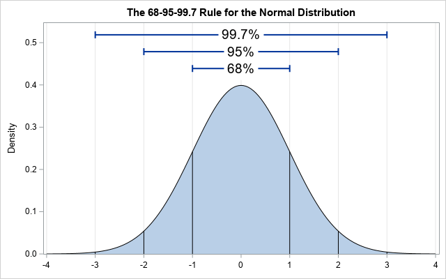

Normal Distribution